# 04 playground

```r
library(tidyverse)
library(lme4)
library(lmerTest)
library(HLMdiag)
```

```
## No summary function supplied, defaulting to `mean_se()`
```

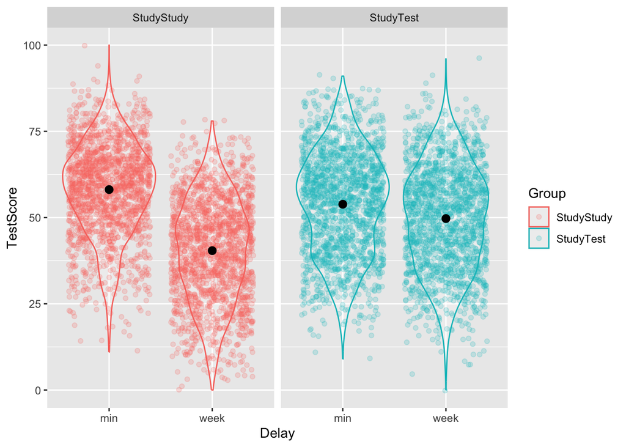

```r
load(url("https://uoepsy.github.io/data/testenhancedlearning.RData"))

ppts_to_keep <- c(
  paste0('StudyStudy_', LETTERS[1:10]),
  paste0('StudyTest_', LETTERS[1:10])
)

set.seed(1)
tel_data <- tel |>
  filter(
    Test_word != 'Eskimo',
    Subject_ID %in% ppts_to_keep
  ) |>
  rowwise() |>
  mutate(
    TestScore = rnorm(n=1, mean = Correct, sd = 0.5),
  ) |>
  ungroup() |>
  mutate(
    TestScore = case_when(
      Group == 'StudyStudy' & Delay == 'min'  ~ TestScore + 0.2,
      Group == 'StudyStudy' & Delay == 'week' ~ TestScore - 0.5,
      Group == 'StudyTest'  & Delay == 'min'  ~ TestScore + 0.2,
      Group == 'StudyTest'  & Delay == 'week' ~ TestScore,
    ),
    TestScore = round(datawizard::rescale(TestScore, to = c(0, 100)))
  )

rm(tel)

tel_data |>
  ggplot(aes(x = Delay, y = TestScore, colour = Group)) +
  geom_violin(alpha = 0.2) +
  geom_jitter(alpha = 0.2) +
  facet_wrap(~ Group) +
  stat_summary(geom = 'pointrange', colour = 'black')
```

# TEL TestScore lm

## simplify models

if so, will have to update lec 3 about this as well

```r
# singular fit
m1 <- lmer(
  TestScore ~ Delay * Group +
    (1 + Delay | Subject_ID) +
    (1 + Delay * Group | Test_word),
  data = tel_data
)

# singular fit
m2 <- lmer(
  TestScore ~ Delay * Group +
    (1 + Delay | Subject_ID) +
    (1 + Delay + Group | Test_word),
  data = tel_data
)

m3 <- lmer(
  TestScore ~ Delay * Group +
    (1 + Delay | Subject_ID) +
    (1 + Delay | Test_word),
  data = tel_data
)

# singular fit
m4 <- lmer(
  TestScore ~ Delay * Group +
    (1 | Subject_ID) +
    (1 + Delay | Test_word),
  data = tel_data
)
```

```r
# no singual fit
m5 <- lmer(
  TestScore ~ Delay * Group +
    (1 + Delay | Subject_ID) +
    (1 | Test_word),
  data = tel_data
)

summary(m5)
```

```
## Linear mixed model fit by REML. t-tests use Satterthwaite's method [
## lmerModLmerTest]
## Formula: TestScore ~ Delay * Group + (1 + Delay | Subject_ID) + (1 | Test_word)
##    Data: tel_data
##
## REML criterion at convergence: 55666.6
##
## Scaled residuals:
##     Min      1Q  Median      3Q     Max
## -3.3504 -0.6365  0.0294  0.6695  3.3916
##
## Random effects:
##  Groups     Name        Variance Std.Dev. Corr
##  Test_word  (Intercept)  11.0907  3.3303
##  Subject_ID (Intercept)  33.1255  5.7555
##             Delayweek     0.6365  0.7978  0.19
##  Residual               166.9386 12.9205
## Number of obs: 6959, groups:  Test_word, 174; Subject_ID, 20
##
## Fixed effects:
##                          Estimate Std. Error       df t value Pr(>|t|)
## (Intercept)               58.1051     1.8634  18.6770  31.182  < 2e-16 ***
## Delayweek                -17.6976     0.5056  18.0066 -35.006  < 2e-16 ***
## GroupStudyTest            -4.2471     2.6109  17.9985  -1.627    0.121
## Delayweek:GroupStudyTest  13.5499     0.7149  18.0027  18.953 2.43e-13 ***
## ---
## Signif. codes:  0 '***' 0.001 '**' 0.01 '*' 0.05 '.' 0.1 ' ' 1
##
## Correlation of Fixed Effects:
##             (Intr) Delywk GrpStT
## Delayweek   -0.008
## GropStdyTst -0.701  0.006
## Dlywk:GrpST  0.006 -0.707 -0.009
```

## check assump

### linearity

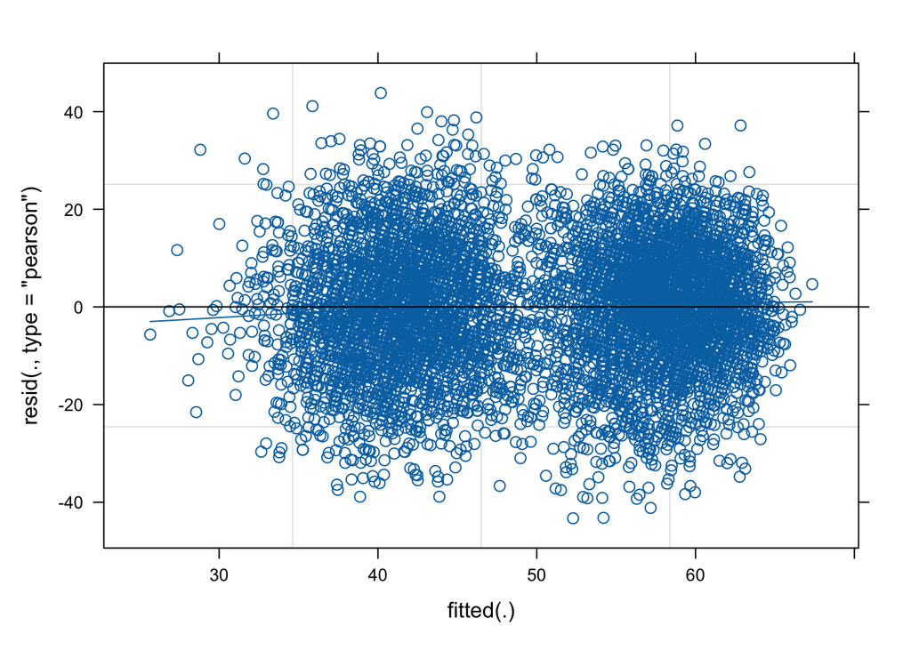

```r
plot(
  m5,
  type=c(
    "p",      # includes points representing Pearson residuals
    "smooth"  # includes smoothed line representing mean of residuals
  )
)
```

two weird clouds, kind of bimodal distribution of test scores evidently, but fine

horizontal enough!

### normdist errors

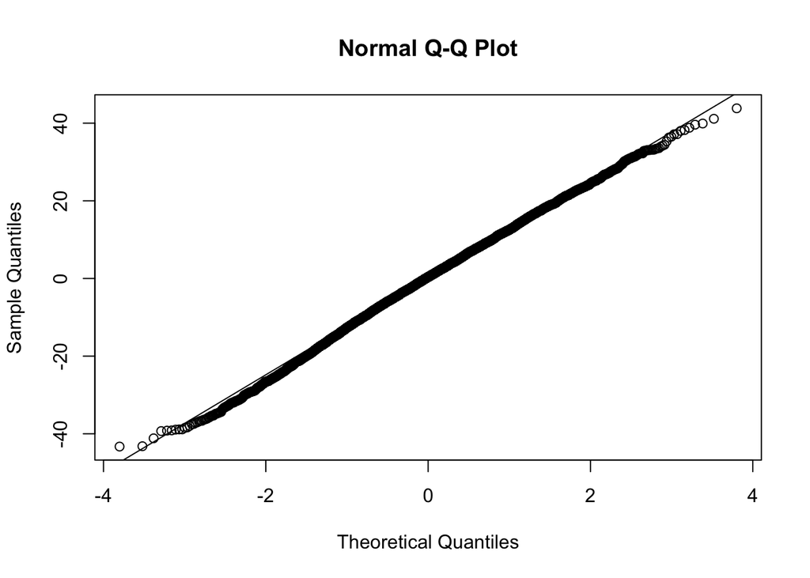

```r
qqnorm(resid(m5))
qqline(resid(m5))
```

pretty darn good

### equal varc errors

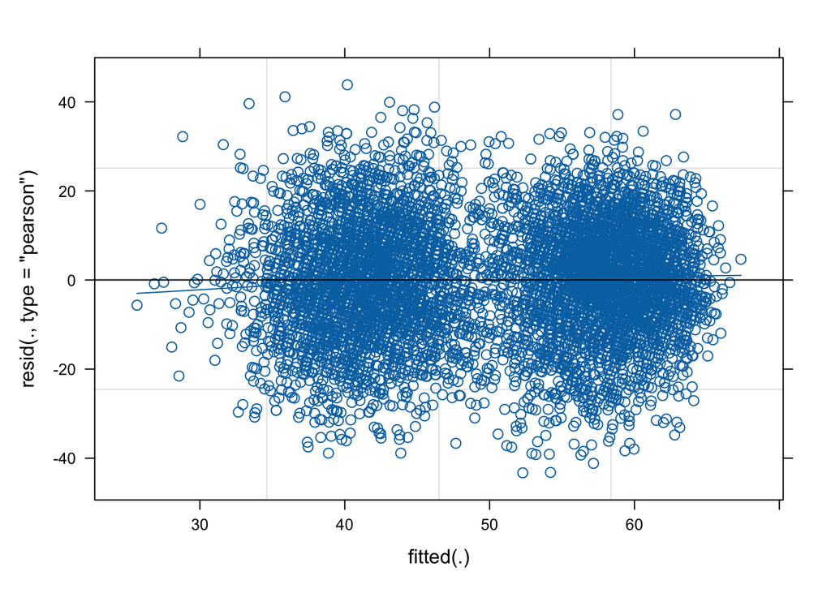

```r
plot(
  m5,
  type=c(
    "p",      # includes points representing Pearson residuals
    "smooth"  # includes smoothed line representing mean of residuals
  )
)
```

vertical spread of errors is OK no fan or funnel shapes, which is what we generally would be worried about

fine.

### normdist ranefs

#### by-ppt int adjs

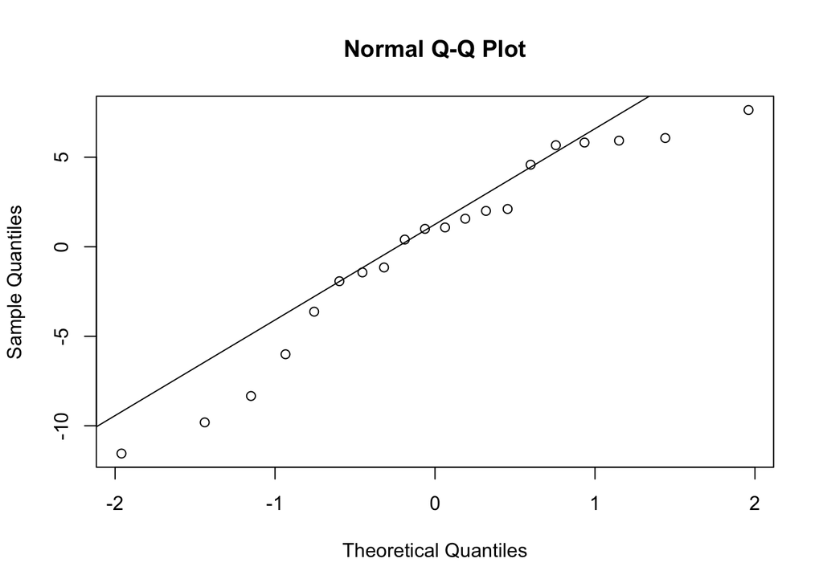

```r
qqnorm(ranef(m5)$Subject_ID[,1])
qqline(ranef(m5)$Subject_ID[,1])
```

not a great match … positive adjustments are closer to zero than would be ideal, and negative adjustments are farther from zero than would be ideal

so in this case, would be something to report and just say that we gotta take the SD with a grain of salt

#### by-ppt slp adjs

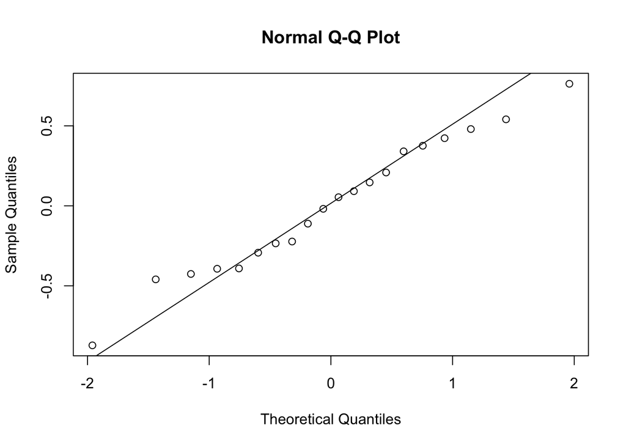

```r
qqnorm(ranef(m5)$Subject_ID[,2])
qqline(ranef(m5)$Subject_ID[,2])
```

better ish fit

#### by-word int adjs

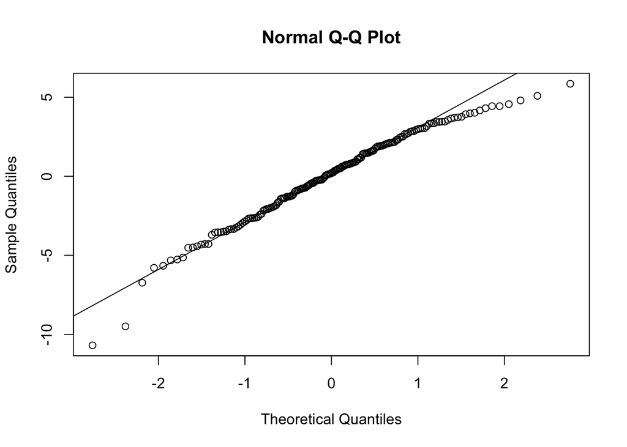

```r
qqnorm(ranef(m5)$Test_word[,1])
qqline(ranef(m5)$Test_word[,1])
```

again, some more negative residuals at the lower end and some also smaller residuals at the pos end but w/e it’s close enough, not too severe

## checking influential obs and groups

```r
inf_obs  <- hlm_influence(model = m5, level = 1, approx = TRUE)
inf_subj <- hlm_influence(model = m5, level = "Subject_ID", approx = TRUE)
inf_word <- hlm_influence(model = m5, level = "Test_word", approx = TRUE)

#save to rda file
save(inf_obs,  file = "../data/m5_inf_obs.rda")
save(inf_subj, file = "../data/m5_inf_subj.rda")
save(inf_word, file = "../data/m5_inf_word.rda")
```

```r
load("../data/m5_inf_obs.rda")
load("../data/m5_inf_subj.rda")
load("../data/m5_inf_word.rda")
```

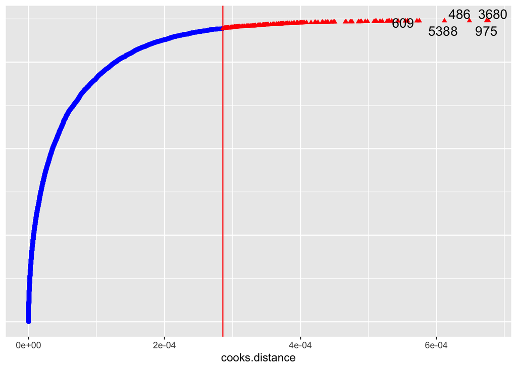

```r
dotplot_diag(inf_obs$cooksd, cutoff = "internal")
```

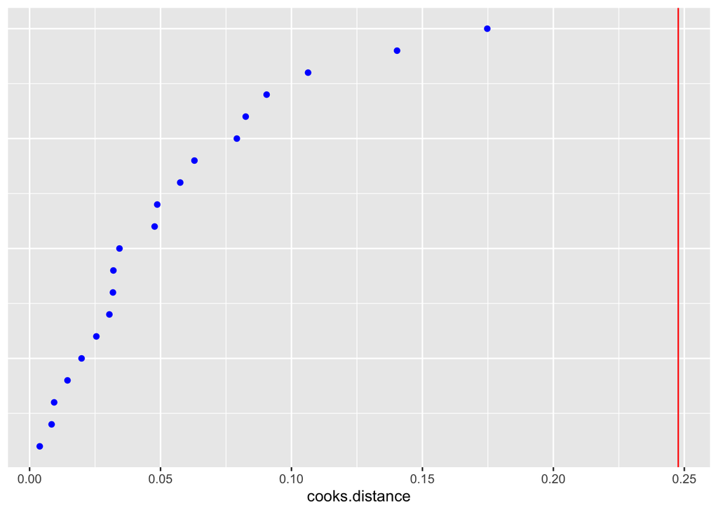

```r
dotplot_diag(inf_subj$cooksd, index = inf_subj$Subject_ID, cutoff = "internal")
```

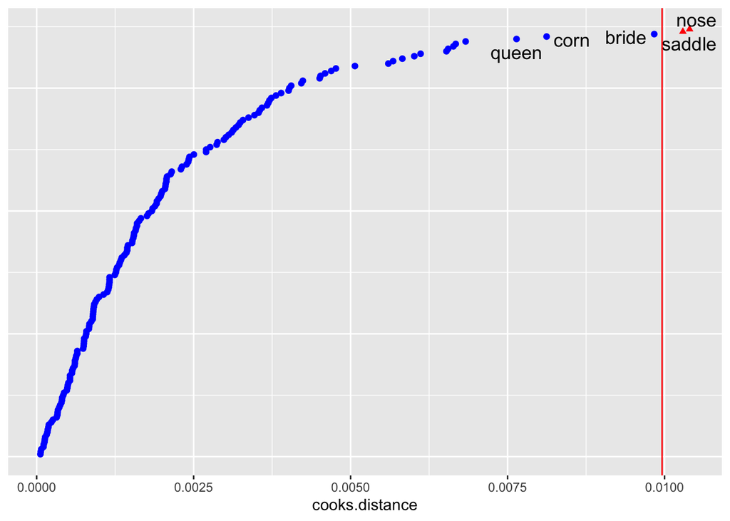

```r
dotplot_diag(inf_word$cooksd, index = inf_word$Test_word, cutoff = "internal")
```

```r
inf_word$Test_word[137]
inf_word$Test_word[61]
```

[output not shown]

### sensitivity analysis

https://uoepsy.github.io/dapr3/2627/flashcards/block1/influence.html

Check on the influence of each of these words individually

#### noseless

```r
m5_noseless <- lmer(
  TestScore ~ Delay * Group +
    (1 + Delay | Subject_ID) +
    (1 | Test_word),
  data = tel_data |> filter(Test_word != "nose")
)
```

```r
summary(m5)
```

```
## Linear mixed model fit by REML. t-tests use Satterthwaite's method [
## lmerModLmerTest]
## Formula: TestScore ~ Delay * Group + (1 + Delay | Subject_ID) + (1 | Test_word)
##    Data: tel_data
##
## REML criterion at convergence: 55666.6
##
## Scaled residuals:
##     Min      1Q  Median      3Q     Max
## -3.3504 -0.6365  0.0294  0.6695  3.3916
##
## Random effects:
##  Groups     Name        Variance Std.Dev. Corr
##  Test_word  (Intercept)  11.0907  3.3303
##  Subject_ID (Intercept)  33.1255  5.7555
##             Delayweek     0.6365  0.7978  0.19
##  Residual               166.9386 12.9205
## Number of obs: 6959, groups:  Test_word, 174; Subject_ID, 20
##
## Fixed effects:
##                          Estimate Std. Error       df t value Pr(>|t|)
## (Intercept)               58.1051     1.8634  18.6770  31.182  < 2e-16 ***
## Delayweek                -17.6976     0.5056  18.0066 -35.006  < 2e-16 ***
## GroupStudyTest            -4.2471     2.6109  17.9985  -1.627    0.121
## Delayweek:GroupStudyTest  13.5499     0.7149  18.0027  18.953 2.43e-13 ***
## ---
## Signif. codes:  0 '***' 0.001 '**' 0.01 '*' 0.05 '.' 0.1 ' ' 1
##
## Correlation of Fixed Effects:
##             (Intr) Delywk GrpStT
## Delayweek   -0.008
## GropStdyTst -0.701  0.006
## Dlywk:GrpST  0.006 -0.707 -0.009
```

```r
summary(m5_noseless)
```

```
## Linear mixed model fit by REML. t-tests use Satterthwaite's method [
## lmerModLmerTest]
## Formula: TestScore ~ Delay * Group + (1 + Delay | Subject_ID) + (1 | Test_word)
##    Data: filter(tel_data, Test_word != "nose")
##
## REML criterion at convergence: 55345.6
##
## Scaled residuals:
##     Min      1Q  Median      3Q     Max
## -3.3496 -0.6388  0.0286  0.6699  3.3919
##
## Random effects:
##  Groups     Name        Variance Std.Dev. Corr
##  Test_word  (Intercept)  11.1225  3.3350
##  Subject_ID (Intercept)  33.3186  5.7722
##             Delayweek     0.6418  0.8011  0.20
##  Residual               166.8948 12.9188
## Number of obs: 6919, groups:  Test_word, 173; Subject_ID, 20
##
## Fixed effects:
##                          Estimate Std. Error       df t value Pr(>|t|)
## (Intercept)               58.1143     1.8689  18.6790  31.096  < 2e-16 ***
## Delayweek                -17.7935     0.5071  18.0069 -35.087  < 2e-16 ***
## GroupStudyTest            -4.2721     2.6185  17.9987  -1.632     0.12
## Delayweek:GroupStudyTest  13.6820     0.7171  18.0029  19.078 2.16e-13 ***
## ---
## Signif. codes:  0 '***' 0.001 '**' 0.01 '*' 0.05 '.' 0.1 ' ' 1
##
## Correlation of Fixed Effects:
##             (Intr) Delywk GrpStT
## Delayweek   -0.006
## GropStdyTst -0.701  0.004
## Dlywk:GrpST  0.004 -0.707 -0.006
```

#### saddleless

```r
m5_saddleless <- lmer(
  TestScore ~ Delay * Group +
    (1 + Delay | Subject_ID) +
    (1 | Test_word),
  data = tel_data |> filter(Test_word != "saddle")
)
```

```r
summary(m5_saddleless)
```

```
## Linear mixed model fit by REML. t-tests use Satterthwaite's method [
## lmerModLmerTest]
## Formula: TestScore ~ Delay * Group + (1 + Delay | Subject_ID) + (1 | Test_word)
##    Data: filter(tel_data, Test_word != "saddle")
##
## REML criterion at convergence: 55336.6
##
## Scaled residuals:
##     Min      1Q  Median      3Q     Max
## -3.3516 -0.6368  0.0295  0.6696  3.3939
##
## Random effects:
##  Groups     Name        Variance Std.Dev. Corr
##  Test_word  (Intercept)  11.1441  3.3383
##  Subject_ID (Intercept)  33.1317  5.7560
##             Delayweek     0.6308  0.7942  0.16
##  Residual               166.6704 12.9101
## Number of obs: 6919, groups:  Test_word, 173; Subject_ID, 20
##
## Fixed effects:
##                          Estimate Std. Error       df t value Pr(>|t|)
## (Intercept)               58.1144     1.8639  18.6873  31.180  < 2e-16 ***
## Delayweek                -17.6641     0.5058  18.0064 -34.924  < 2e-16 ***
## GroupStudyTest            -4.3000     2.6113  18.0016  -1.647    0.117
## Delayweek:GroupStudyTest  13.6133     0.7153  18.0024  19.033 2.26e-13 ***
## ---
## Signif. codes:  0 '***' 0.001 '**' 0.01 '*' 0.05 '.' 0.1 ' ' 1
##
## Correlation of Fixed Effects:
##             (Intr) Delywk GrpStT
## Delayweek   -0.024
## GropStdyTst -0.701  0.017
## Dlywk:GrpST  0.017 -0.707 -0.025
```

# TEL GLM – nah

nah bc

- GLM assumptions are different
- the GLM actually fits out of the gate, don’t need to simplify ranefs

```r
# takes a while
m1 <- lmer(
  Correct ~ Delay * Group +
    (1 + Delay | Subject_ID) +
    (1 + Delay * Group | Test_word),
  data = tel_data,
)

summary(m1)
```